# EDA - Raw Data File and Variable Exploration

Mandip Farmahan

2023-06-09

```r
# import libraries
library(tidyverse)
library(here)
library(janitor)
library(GGally)
library(ggfortify)
library(geosphere)
```

```r
# import datasets
airlines_df <- read_csv(here("data/raw_data/airlines.csv"))
airports_df <- read_csv(here("data/raw_data/airports.csv"))
flights_df <- read_csv(here("data/raw_data/flights.csv"))
planes_df <-  read_csv(here("data/raw_data/planes.csv"))
weather_df <- read_csv(here("data/raw_data/weather.csv"))

noaa_weather_df <- read_csv(here("data/raw_data/weather_noaa_ghcnd.csv")) %>%
    clean_names()
meteostat_ewr <- read_csv(here("data/raw_data/weather_meteostat_ewr.csv"))
meteostat_jfk <- read_csv(here("data/raw_data/weather_meteostat_jfk.csv"))
meteostat_lga <- read_csv(here("data/raw_data/weather_meteostat_lga.csv"))
```

# Combine datasets

## Flight details

### Initial inspection and check for missing values

```r
flights_df %>%
  head()
```

```
## # A tibble: 6 × 19
##    year month   day dep_time sched_dep_time dep_delay arr_time sched_arr_time
##   <dbl> <dbl> <dbl>    <dbl>          <dbl>     <dbl>    <dbl>          <dbl>
## 1  2017    10     1       27           2114       193      317             15
## 2  2017    10     1      519            525        -6      741            759
## 3  2017    10     1      544            545        -1      815            819
## 4  2017    10     1      546            550        -4      702            719
## 5  2017    10     1      552            600        -8      846            850
## 6  2017    10     1      553            600        -7      852            858
## # ℹ 11 more variables: arr_delay <dbl>, carrier <chr>, flight <dbl>,
## #   tailnum <chr>, origin <chr>, dest <chr>, air_time <dbl>, distance <dbl>,
## #   hour <dbl>, minute <dbl>, time_hour <dttm>
```

```r
flights_df %>%
  count(origin)
```

```
## # A tibble: 3 × 2
##   origin      n
##   <chr>   <int>
## 1 EWR    115968
## 2 JFK     94454
## 3 LGA     93326
```

```r
flights_df %>%
  count(dest)
```

```
## # A tibble: 109 × 2
##    dest      n
##    <chr> <int>
##  1 ABQ     313
##  2 ACK     432
##  3 ALB      72
##  4 ANC      13
##  5 ATL   16845
##  6 AUS    3411
##  7 AVL     332
##  8 AVP     214
##  9 BDL     277
## 10 BGR     501
## # ℹ 99 more rows
```

```r
flights_df %>%
  summarise(across(.cols = everything(),
                   .fns = ~sum(is.na(.x))),
            .by = c(origin))
```

```
## # A tibble: 3 × 19
##   origin  year month   day dep_time sched_dep_time dep_delay arr_time
##   <chr>  <int> <int> <int>    <int>          <int>     <int>    <int>
## 1 EWR        0     0     0     2901              0      2903     3026
## 2 LGA        0     0     0     2936              0      2938     3028
## 3 JFK        0     0     0     1973              0      1973     2094
## # ℹ 11 more variables: sched_arr_time <int>, arr_delay <int>, carrier <int>,
## #   flight <int>, tailnum <int>, dest <int>, air_time <int>, distance <int>,
## #   hour <int>, minute <int>, time_hour <int>
```

```r
flights_df %>%
  summarise(across(.cols = everything(),
                   .fns = ~sum(.x == 0, na.rm = TRUE)),
            .by = c(origin))
```

```
## # A tibble: 3 × 19
##   origin  year month   day dep_time sched_dep_time dep_delay arr_time
##   <chr>  <int> <int> <int>    <int>          <int>     <int>    <int>
## 1 EWR        0     0     0        0              0      4075        0
## 2 LGA        0     0     0        0              0      4296        0
## 3 JFK        0     0     0        0              0      4250        0
## # ℹ 11 more variables: sched_arr_time <int>, arr_delay <int>, carrier <int>,
## #   flight <int>, tailnum <int>, dest <int>, air_time <int>, distance <int>,
## #   hour <int>, minute <int>, time_hour <int>
```

```r
flights_df %>%
  summarise(across(.cols = everything(),
                   .fns = ~sum(is.na(.x))),
            .by = c(month))
```

```
## # A tibble: 12 × 19
##    month  year   day dep_time sched_dep_time dep_delay arr_time sched_arr_time
##    <dbl> <int> <int>    <int>          <int>     <int>    <int>          <int>
##  1    10     0     0      423              0       423      436              0
##  2    11     0     0       55              0        55       58              0
##  3    12     0     0      203              0       203      222              0
##  4     1     0     0      512              0       512      542              0
##  5     2     0     0      978              0       979      998              0
##  6     3     0     0     1392              0      1392     1410              0
##  7     4     0     0      513              0       513      534              0
##  8     5     0     0      576              0       576      607              0
##  9     6     0     0      547              0       549      607              0
## 10     7     0     0      769              0       769      824              0
## 11     8     0     0      830              0       830      881              0
## 12     9     0     0     1012              0      1013     1029              0
## # ℹ 11 more variables: arr_delay <int>, carrier <int>, flight <int>,
## #   tailnum <int>, origin <int>, dest <int>, air_time <int>, distance <int>,
## #   hour <int>, minute <int>, time_hour <int>
```

Lots of missing dep_time values (2.6% of dataset) and they seem to be spread across all airports and all months. This data cannot be imputed as there is no similar to data to leverage, esp as these form the main output measure. There also appears to be a few extra missing in the dep_delay column. They will therefore be removed from the dataset.

```r
flights_df %>%
  filter(is.na(dep_time)) %>%
  filter(is.na(dep_delay))
```

```
## # A tibble: 7,810 × 19
##     year month   day dep_time sched_dep_time dep_delay arr_time sched_arr_time
##    <dbl> <dbl> <dbl>    <dbl>          <dbl>     <dbl>    <dbl>          <dbl>
##  1  2017    10     1       NA           2110        NA       NA            100
##  2  2017    10     1       NA           2245        NA       NA             52
##  3  2017    10     1       NA           2100        NA       NA             27
##  4  2017    10     1       NA           1100        NA       NA           1452
##  5  2017    10     1       NA           1416        NA       NA           1814
##  6  2017    10     1       NA           2359        NA       NA            348
##  7  2017    10     1       NA            740        NA       NA           1132
##  8  2017    10     1       NA           1547        NA       NA           1907
##  9  2017    10     1       NA            650        NA       NA           1049
## 10  2017    10     1       NA           2359        NA       NA            347
## # ℹ 7,800 more rows
## # ℹ 11 more variables: arr_delay <dbl>, carrier <chr>, flight <dbl>,
## #   tailnum <chr>, origin <chr>, dest <chr>, air_time <dbl>, distance <dbl>,
## #   hour <dbl>, minute <dbl>, time_hour <dttm>
```

```r
flights_df %>%
  filter(!is.na(dep_time)) %>%
  filter(is.na(dep_delay))
```

```
## # A tibble: 4 × 19
##    year month   day dep_time sched_dep_time dep_delay arr_time sched_arr_time
##   <dbl> <dbl> <dbl>    <dbl>          <dbl>     <dbl>    <dbl>          <dbl>
## 1  2017     2    25     1524           1524        NA       NA           1727
## 2  2017     6    19     1330           1330        NA       NA           1520
## 3  2017     6    19     1340           1340        NA       NA           1554
## 4  2017     9     5     1630           1630        NA       NA           1820
## # ℹ 11 more variables: arr_delay <dbl>, carrier <chr>, flight <dbl>,
## #   tailnum <chr>, origin <chr>, dest <chr>, air_time <dbl>, distance <dbl>,
## #   hour <dbl>, minute <dbl>, time_hour <dttm>
```

```r
flights_df %>%
  filter(abs(dep_delay) < 1)
```

```
## # A tibble: 12,621 × 19
##     year month   day dep_time sched_dep_time dep_delay arr_time sched_arr_time
##    <dbl> <dbl> <dbl>    <dbl>          <dbl>     <dbl>    <dbl>          <dbl>
##  1  2017    10     1      623            623         0      904            859
##  2  2017    10     1      710            710         0      913            936
##  3  2017    10     1      807            807         0     1052           1118
##  4  2017    10     1      830            830         0     1102           1114
##  5  2017    10     1      837            837         0     1132           1153
##  6  2017    10     1      905            905         0     1143           1156
##  7  2017    10     1     1056           1056         0     1344           1414
##  8  2017    10     1     1125           1125         0     1408           1416
##  9  2017    10     1     1135           1135         0     1312           1329
## 10  2017    10     1     1235           1235         0     1435           1457
## # ℹ 12,611 more rows
## # ℹ 11 more variables: arr_delay <dbl>, carrier <chr>, flight <dbl>,
## #   tailnum <chr>, origin <chr>, dest <chr>, air_time <dbl>, distance <dbl>,
## #   hour <dbl>, minute <dbl>, time_hour <dttm>
```

Appears that these additional missing values should have been set to 0 based on dep_time minus sched_dep_time.

### First pass cleanup

The United States Federal Aviation Administration (FAA) considers a flight to be delayed when it is 15 minutes later than its scheduled time.

If there is no departure time, it is assumed that flight was cancelled.

```r
flights_final <- flights_df %>%
  # create a single date/time reference for each flight
  mutate(sch_departure = ISOdate(year, month, day, hour, minute),
         .before = year) %>%
  # create a column for joining with additional weather dataset
  mutate(date = as.Date(paste(year, month, day), "%Y%m%d"),
       .before = year) %>%
  mutate(dep_delay = case_when(is.na(dep_time) ~ NA, # cancelled flight
                               is.na(dep_delay) ~ 0, # no delay
                               .default = dep_delay),
         delay_flag = case_when(is.na(dep_time) ~ "Cancelled", # cancelled flight
                                dep_delay < 15 ~ "No", # no delay
                                .default = "Yes")) %>%
  # extract only the columns required for final analysis
  select(sch_departure, origin, dest, dep_delay, delay_flag,
         carrier, flight, tailnum, distance,
         time_hour, date)

head(flights_final)
```

```
## # A tibble: 6 × 11
##   sch_departure       origin dest  dep_delay delay_flag carrier flight tailnum
##   <dttm>              <chr>  <chr>     <dbl> <chr>      <chr>    <dbl> <chr>
## 1 2017-10-01 21:14:00 EWR    MIA         193 Yes        UA        1537 N54711
## 2 2017-10-01 05:25:00 EWR    IAH          -6 No         UA        1161 N37287
## 3 2017-10-01 05:45:00 EWR    MCO          -1 No         B6          27 N547JB
## 4 2017-10-01 05:50:00 LGA    ORD          -4 No         UA         761 N38446
## 5 2017-10-01 06:00:00 EWR    FLL          -8 No         NK         521 N675NK
## 6 2017-10-01 06:00:00 JFK    LAX          -7 No         B6          23 N967JB
## # ℹ 3 more variables: distance <dbl>, time_hour <dttm>, date <date>
```

```r
flights_final %>%
  count(delay_flag)
```

```
## # A tibble: 3 × 2
##   delay_flag      n
##   <chr>       <int>
## 1 Cancelled    7810
## 2 No         227420
## 3 Yes         68518
```

```r
flights_final %>%
  summarise(across(.cols = everything(),
                   .fns = ~sum(is.na(.x))),
            .by = c(origin))
```

```
## # A tibble: 3 × 11
##   origin sch_departure  dest dep_delay delay_flag carrier flight tailnum
##   <chr>          <int> <int>     <int>      <int>   <int>  <int>   <int>
## 1 EWR                0     0      2901          0       0      0     722
## 2 LGA                0     0      2936          0       0      0     243
## 3 JFK                0     0      1973          0       0      0      26
## # ℹ 3 more variables: distance <int>, time_hour <int>, date <int>
```

```r
flights_final %>%
  summarise(across(.cols = everything(),
                   .fns = ~sum(.x == 0)),
            .by = c(origin))
```

```
## # A tibble: 3 × 11
##   origin sch_departure  dest dep_delay delay_flag carrier flight tailnum
##   <chr>          <int> <int>     <int>      <int>   <int>  <int>   <int>
## 1 EWR                0     0        NA          0       0      0      NA
## 2 LGA                0     0        NA          0       0      0      NA
## 3 JFK                0     0        NA          0       0      0      NA
## # ℹ 3 more variables: distance <int>, time_hour <int>, date <int>
```

```r
flights_final %>%
  select(-c(sch_departure, time_hour, date)) %>%
  summary()
```

```
##     origin              dest             dep_delay        delay_flag
##  Length:303748      Length:303748      Min.   : -84.00   Length:303748
##  Class :character   Class :character   1st Qu.:  -6.00   Class :character
##  Mode  :character   Mode  :character   Median :  -2.00   Mode  :character
##                                        Mean   :  15.19
##                                        3rd Qu.:  12.00
##                                        Max.   :1548.00
##                                        NA's   :7810
##    carrier              flight       tailnum             distance
##  Length:303748      Min.   :   1   Length:303748      Min.   :  93
##  Class :character   1st Qu.: 519   Class :character   1st Qu.: 636
##  Mode  :character   Median :1345   Mode  :character   Median :1005
##                     Mean   :1699                      Mean   :1154
##                     3rd Qu.:2238                      3rd Qu.:1598
##                     Max.   :6988                      Max.   :4983
##
```

From the dep_delay summary, it looks like some flights took off almost 1.5 hours early!

#### Plot the spead of delays

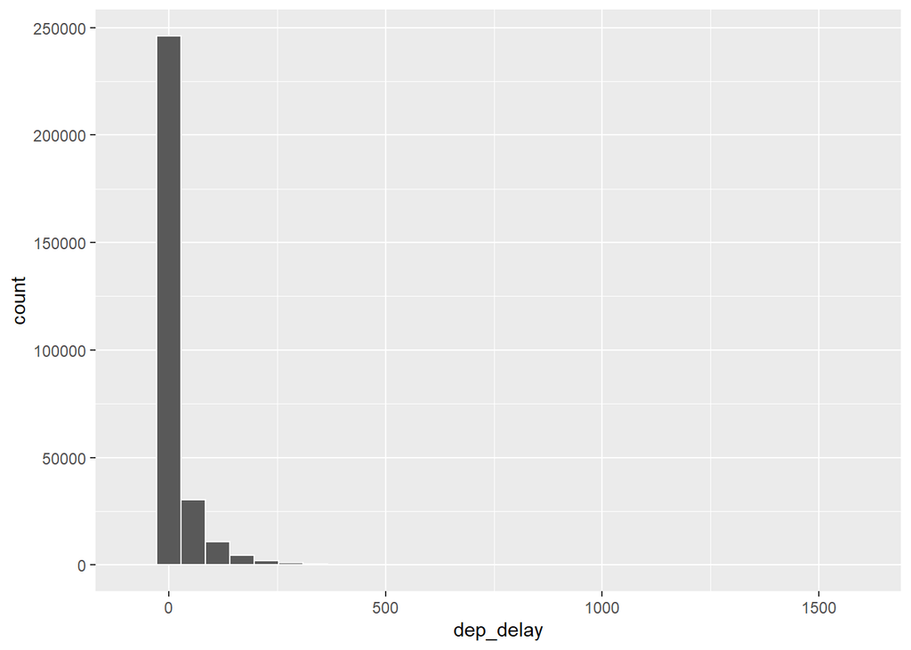

```r
# all flights
flights_final %>%
  ggplot(aes(x = dep_delay))+
  geom_histogram(colour = "white")
```

#### Plot the spead of flights leaving early

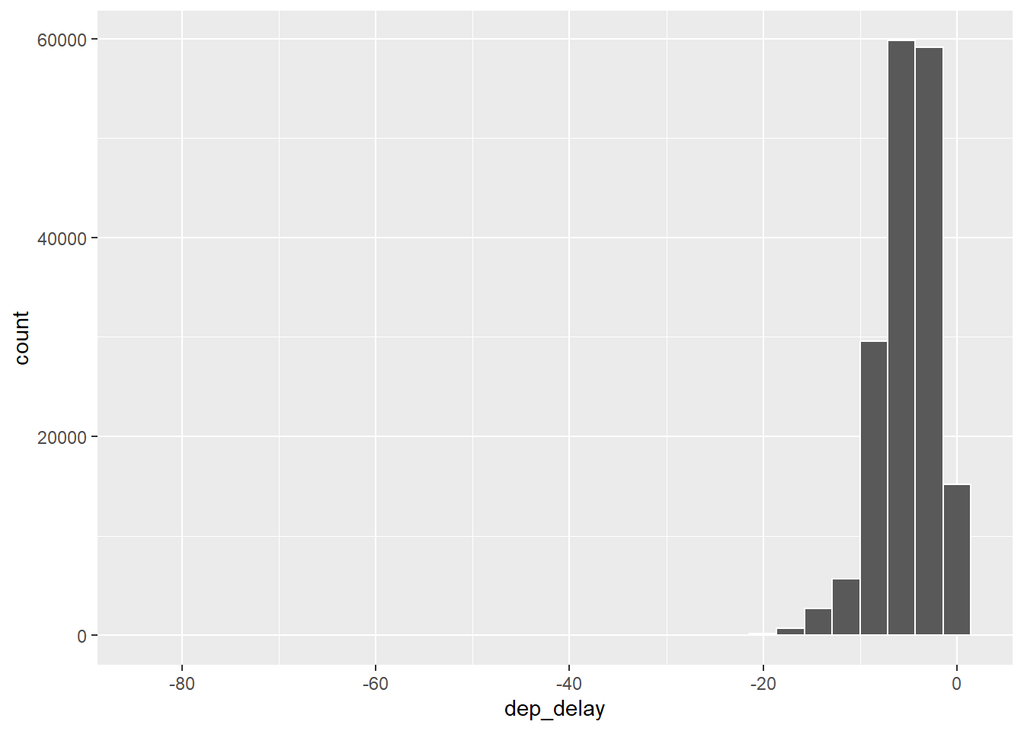

```r
flights_final %>%
  filter(dep_delay < 0) %>%
  ggplot(aes(x = dep_delay))+
  geom_histogram(colour = "white")
```

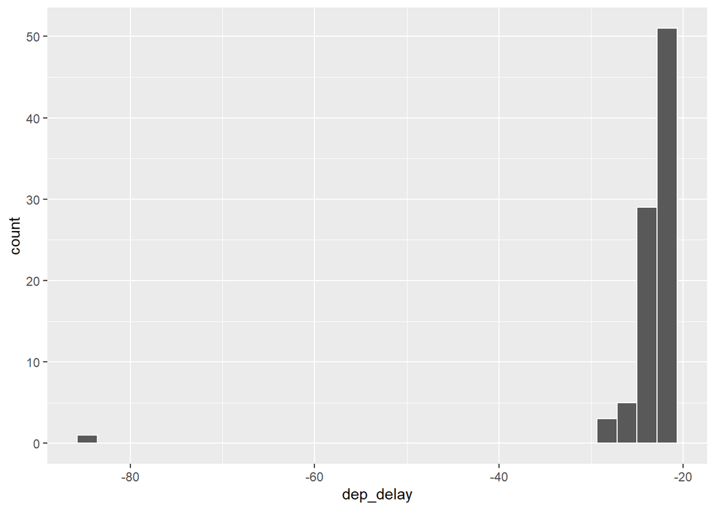

```r
flights_final %>%
  filter(dep_delay < -20) %>%
  ggplot(aes(x = dep_delay))+
  geom_histogram(colour = "white")
```

```r
flights_final %>%
  filter(dep_delay < -25)
```

```
## # A tibble: 6 × 11
##   sch_departure       origin dest  dep_delay delay_flag carrier flight tailnum
##   <dttm>              <chr>  <chr>     <dbl> <chr>      <chr>    <dbl> <chr>
## 1 2017-10-14 08:30:00 LGA    DTW         -28 No         NK         475 N626NK
## 2 2017-10-28 21:55:00 LGA    ORD         -29 No         NK         331 N675NK
## 3 2017-10-31 21:30:00 LGA    ORD         -26 No         AA         321 N3PLAA
## 4 2017-11-15 08:38:00 LGA    ORD         -27 No         NK         847 N526NK
## 5 2017-09-02 20:30:00 JFK    SFO         -28 No         B6        1415 N929JB
## 6 2017-09-25 08:05:00 JFK    SJU         -84 No         DL         436 N536US
## # ℹ 3 more variables: distance <dbl>, time_hour <dttm>, date <date>
```

```r
flights_df %>%
  filter(dep_delay < -25)
```

```
## # A tibble: 6 × 19
##    year month   day dep_time sched_dep_time dep_delay arr_time sched_arr_time
##   <dbl> <dbl> <dbl>    <dbl>          <dbl>     <dbl>    <dbl>          <dbl>
## 1  2017    10    14      802            830       -28      948           1023
## 2  2017    10    28     2126           2155       -29     2233           2319
## 3  2017    10    31     2104           2130       -26     2225           2309
## 4  2017    11    15      811            838       -27      940           1015
## 5  2017     9     2     2002           2030       -28     2254             12
## 6  2017     9    25      641            805       -84     1058           1208
## # ℹ 11 more variables: arr_delay <dbl>, carrier <chr>, flight <dbl>,
## #   tailnum <chr>, origin <chr>, dest <chr>, air_time <dbl>, distance <dbl>,
## #   hour <dbl>, minute <dbl>, time_hour <dttm>
```

#### Plot the spread of delayed flights

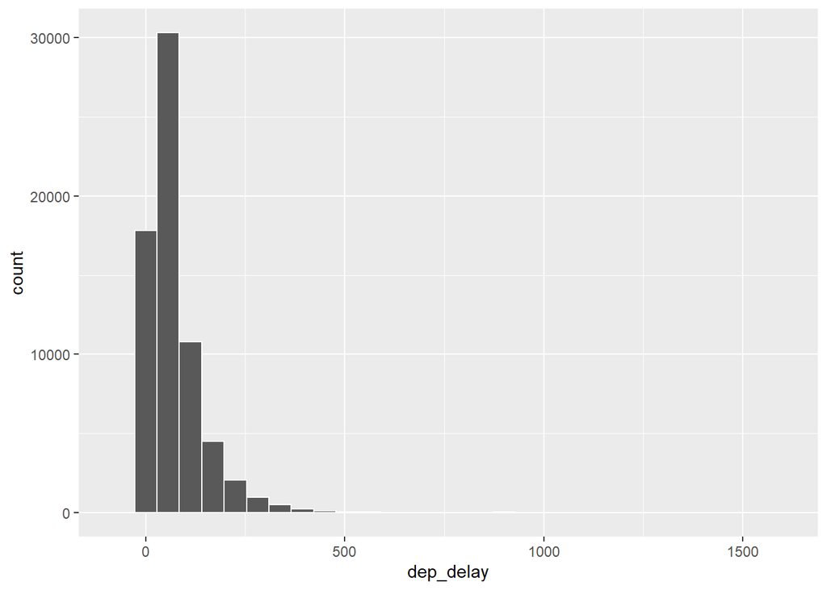

```r
# 15 mins late
flights_final %>%
  filter(abs(dep_delay) > 15) %>%
  ggplot(aes(x = dep_delay))+
  geom_histogram(colour = "white")
```

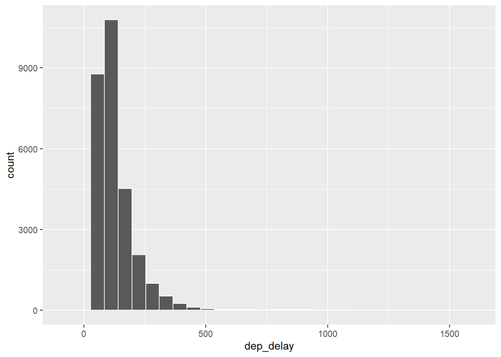

```r
# 60 mins late
flights_final %>%
  filter(abs(dep_delay) > 60) %>%
  ggplot(aes(x = dep_delay))+
  geom_histogram(colour = "white")
```

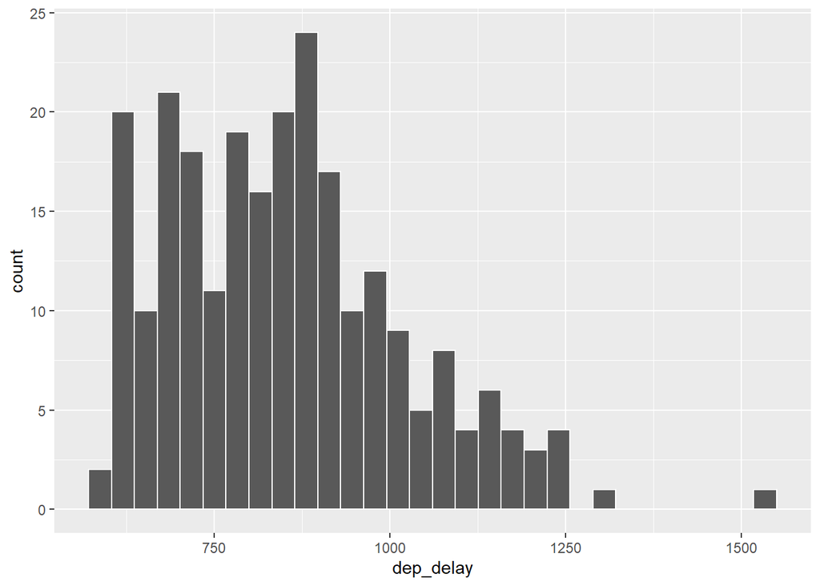

```r
# 10 hours late
flights_final %>%
  filter(abs(dep_delay) > 600) %>%
  ggplot(aes(x = dep_delay))+
  geom_histogram(colour = "white")
```

It seems that some delays are next day flight, i.e. approx 24 hours later.

## Weather details

### Original dataset

#### Initial inspection and check for missing values

```r
weather_df %>%
  head()
```

```
## # A tibble: 6 × 15
##   origin  year month   day  hour  temp  dewp humid wind_dir wind_speed wind_gust
##   <chr>  <dbl> <dbl> <dbl> <dbl> <dbl> <dbl> <dbl>    <dbl>      <dbl>     <dbl>
## 1 EWR     2017     1     1     0    NA    NA    NA      200      17.3      19.9
## 2 EWR     2017     1     1     1    NA    NA    NA      220      16.1      18.5
## 3 EWR     2017     1     1     2    NA    NA    NA      190      11.5      13.2
## 4 EWR     2017     1     1     3    NA    NA    NA      190       8.06      9.27
## 5 EWR     2017     1     1     4    NA    NA    NA      220       9.21     10.6
## 6 EWR     2017     1     1     5    NA    NA    NA      220      11.5      13.2
## # ℹ 4 more variables: precip <dbl>, pressure <dbl>, visib <dbl>,
## #   time_hour <dttm>
```

```r
weather_df %>%
  summarise(across(.cols = everything(),
                   .fns = ~sum(is.na(.x))),
            .by = origin)
```

```
## # A tibble: 3 × 15
##   origin  year month   day  hour  temp  dewp humid wind_dir wind_speed wind_gust
##   <chr>  <int> <int> <int> <int> <int> <int> <int>    <int>      <int>     <int>
## 1 EWR        0     0     0     0  8531  8531  8531      629        617       617
## 2 JFK        0     0     0     0  8560  8560  8560      872        870       870
## 3 LGA        0     0     0     0  8551  8551  8551     1160       1160      1160
## # ℹ 4 more variables: precip <int>, pressure <int>, visib <int>,
## #   time_hour <int>
```

```r
weather_df %>%
  summarise(across(.cols = everything(),
                   .fns = ~sum(.x == 0, na.rm = TRUE)),
            .by = origin)
```

```
## # A tibble: 3 × 15
##   origin  year month   day  hour  temp  dewp humid wind_dir wind_speed wind_gust
##   <chr>  <int> <int> <int> <int> <int> <int> <int>    <int>      <int>     <int>
## 1 EWR        0     0     0   364     0     0     0      464        464       464
## 2 JFK        0     0     0   364     0     0     0      285        285       285
## 3 LGA        0     0     0   364     0     0     0      276        276       276
## # ℹ 4 more variables: precip <int>, pressure <int>, visib <int>,
## #   time_hour <int>
```

About 98% of the temperature, dew point, humidity, precipitation and pressure data is missing. This will be supplemented with an alternative source of data.

About 10% of the wind direction, wind speed and wind gust data is missing. There also seems o be a lot with zero values, i.e. no wind. An alternative source will be investigated or the data will be imputed using the daily median for each airport at the final join in case there are any missing time points in this dataset, which will lead to NAs in the final dataset.

#### First pass cleanup

```r
weather_final <- weather_df %>%
  select(origin, time_hour, wind_dir, wind_speed, wind_gust, visib)

head(weather_final)
```

```
## # A tibble: 6 × 6
##   origin time_hour           wind_dir wind_speed wind_gust visib
##   <chr>  <dttm>                 <dbl>      <dbl>     <dbl> <dbl>
## 1 EWR    2017-01-01 08:00:00      200      17.3      19.9     10
## 2 EWR    2017-01-01 09:00:00      220      16.1      18.5     10
## 3 EWR    2017-01-01 10:00:00      190      11.5      13.2     10
## 4 EWR    2017-01-01 11:00:00      190       8.06      9.27    10
## 5 EWR    2017-01-01 12:00:00      220       9.21     10.6     10
## 6 EWR    2017-01-01 13:00:00      220      11.5      13.2     10
```

```r
weather_final %>%
  select(-time_hour) %>%
  summary()
```

```
##     origin             wind_dir       wind_speed       wind_gust
##  Length:26201       Min.   :  0.0   Min.   : 0.000   Min.   : 0.000
##  Class :character   1st Qu.: 80.0   1st Qu.: 6.905   1st Qu.: 7.946
##  Mode  :character   Median :200.0   Median : 9.206   Median :10.594
##                     Mean   :183.8   Mean   : 9.616   Mean   :11.066
##                     3rd Qu.:270.0   3rd Qu.:12.659   3rd Qu.:14.567
##                     Max.   :360.0   Max.   :39.127   Max.   :45.026
##                     NA's   :2661    NA's   :2647     NA's   :2647
##      visib
##  Min.   : 0.120
##  1st Qu.:10.000
##  Median :10.000
##  Mean   : 9.346
##  3rd Qu.:10.000
##  Max.   :10.000
##  NA's   :11
```

### NOAA weather details

Obtained from:

https://www.ncei.noaa.gov/cdo-web/search?datasetid=GHCND

#### Check for missing values

```r
noaa_weather_df %>%
  summarise(across(.cols = everything(),
                   .fns = ~sum(is.na(.x))))
```

```
## # A tibble: 1 × 24
##   station  name  date  awnd  pgtm  prcp  snow  snwd  tavg  tmax  tmin  tsun
##     <int> <int> <int> <int> <int> <int> <int> <int> <int> <int> <int> <int>
## 1       0     0     0     0  1092     0     0     0     0     0     0  1095
## # ℹ 12 more variables: wdf2 <int>, wdf5 <int>, wsf2 <int>, wsf5 <int>,
## #   wt01 <int>, wt02 <int>, wt03 <int>, wt04 <int>, wt05 <int>, wt06 <int>,
## #   wt08 <int>, wt09 <int>
```

```r
noaa_weather_df %>%
  summarise(across(.cols = everything(),
                   .fns = ~sum(.x == 0, na.rm = TRUE)))
```

```
## # A tibble: 1 × 24
##   station  name  date  awnd  pgtm  prcp  snow  snwd  tavg  tmax  tmin  tsun
##     <int> <int> <int> <int> <int> <int> <int> <int> <int> <int> <int> <int>
## 1       0     0     0     0     0   736  1057  1021     0     0     0     0
## # ℹ 12 more variables: wdf2 <int>, wdf5 <int>, wsf2 <int>, wsf5 <int>,
## #   wt01 <int>, wt02 <int>, wt03 <int>, wt04 <int>, wt05 <int>, wt06 <int>,
## #   wt08 <int>, wt09 <int>
```

No missing values in the columns required (name, date, prcp, snow, snwd, tavg)

```r
noaa_weather_df %>%
  count(wt01)
```

```
## # A tibble: 2 × 2
##    wt01     n
##   <dbl> <int>
## 1     1   378
## 2    NA   717
```

wt01 to wt09 are special category of weather. There is only 2 options in the primary category so this variable will not be used.

#### First pass cleanup

```r
noaa_weather_trim <- noaa_weather_df %>%
  # create FAA airport code to join with original weather dataset
  mutate(origin = case_when(str_starts(name, "LAG") ~ "LGA",
                            str_starts(name, "JFK") ~ "JFK",
                            .default = "EWR")) %>%
  select(date, origin, prcp, snow, snwd, tavg)

head(noaa_weather_trim)
```

```
## # A tibble: 6 × 6
##   date       origin  prcp  snow  snwd  tavg
##   <date>     <chr>  <dbl> <dbl> <dbl> <dbl>
## 1 2017-01-01 LGA     0      0     0      46
## 2 2017-01-02 LGA     0.18   0     0      40
## 3 2017-01-03 LGA     0.45   0     0      42
## 4 2017-01-04 LGA     0      0     0      47
## 5 2017-01-05 LGA     0      0     0      34
## 6 2017-01-06 LGA     0.04   1.3   1.2    32
```

```r
noaa_weather_trim %>%
  select(-date) %>%
  summary()
```

```
##     origin               prcp             snow               snwd
##  Length:1095        Min.   :0.0000   Min.   : 0.00000   Min.   :0.0000
##  Class :character   1st Qu.:0.0000   1st Qu.: 0.00000   1st Qu.:0.0000
##  Mode  :character   Median :0.0000   Median : 0.00000   Median :0.0000
##                     Mean   :0.1218   Mean   : 0.09753   Mean   :0.2136
##                     3rd Qu.:0.0400   3rd Qu.: 0.00000   3rd Qu.:0.0000
##                     Max.   :3.8600   Max.   :10.00000   Max.   :7.9000
##       tavg
##  Min.   :15.00
##  1st Qu.:43.00
##  Median :57.00
##  Mean   :56.58
##  3rd Qu.:71.00
##  Max.   :90.00
```

There is no air pressure details so an additional source will be used for this

### Meteostat dataset

Obtained from:

https://meteostat.net/en/

#### Initial inspection and check for missing values

```r
meteostat_weather_df <- bind_rows(
  list(
    "EWR" = meteostat_ewr,
    "JFK" = meteostat_jfk,
    "LGA" = meteostat_lga
  ),
  .id = "origin"
)

meteostat_weather_df %>%
  head()
```

```
## # A tibble: 6 × 12
##   origin date        tavg  tmin  tmax  prcp  snow  wdir  wspd wpgt   pres tsun
##   <chr>  <date>     <dbl> <dbl> <dbl> <dbl> <dbl> <dbl> <dbl> <lgl> <dbl> <lgl>
## 1 EWR    2017-01-01  44.4  33.1  50   0      0      281   9.4 NA    1021. NA
## 2 EWR    2017-01-02  37.8  32    42.1 0.291  0       30   8.7 NA    1030  NA
## 3 EWR    2017-01-03  40.8  39    44.1 0.429  0       27  12.3 NA      NA  NA
## 4 EWR    2017-01-04  45    33.1  54   0      0      252  15   NA      NA  NA
## 5 EWR    2017-01-05  31.8  26.2  33.1 0      0      250  13.7 NA    1013. NA
## 6 EWR    2017-01-06  30.4  25.2  34   0.059  1.18   331   8.7 NA    1018. NA
```

```r
meteostat_weather_df %>%
  summarise(across(.cols = everything(),
                   .fns = ~sum(is.na(.x))))
```

```
## # A tibble: 1 × 12
##   origin  date  tavg  tmin  tmax  prcp  snow  wdir  wspd  wpgt  pres  tsun
##    <int> <int> <int> <int> <int> <int> <int> <int> <int> <int> <int> <int>
## 1      0     0     0     0     0     0     0   278     0  1095   174  1095
```

```r
meteostat_weather_df %>%
  summarise(across(.cols = everything(),
                   .fns = ~sum(.x == 0, na.rm = TRUE)))
```

```
## # A tibble: 1 × 12
##   origin  date  tavg  tmin  tmax  prcp  snow  wdir  wspd  wpgt  pres  tsun
##    <int> <int> <int> <int> <int> <int> <int> <int> <int> <int> <int> <int>
## 1      0     0     0     0     0   736  1021     4     0     0     0     0
```

Unfortunately there are some NAs in the air pressure column (approx 16% of dataset). As these are daily data, they will be imputed using a weekly median.

#### First pass cleanup

```r
meteostat_weather_trim <- meteostat_weather_df %>%
  mutate(week = isoweek(ymd(meteostat_weather_df$date))) %>%
  mutate(pres = coalesce(pres, round(median(pres, na.rm= TRUE), 1)),
         .by = c(origin, week)) %>%
  select(date, origin, pres)

head(meteostat_weather_trim)
```

```
## # A tibble: 6 × 3
##   date       origin  pres
##   <date>     <chr>  <dbl>
## 1 2017-01-01 EWR    1021.
## 2 2017-01-02 EWR    1030
## 3 2017-01-03 EWR    1024.
## 4 2017-01-04 EWR    1024.
## 5 2017-01-05 EWR    1013.
## 6 2017-01-06 EWR    1018.
```

```r
meteostat_weather_trim %>%
  summarise(across(.cols = everything(),
                   .fns = ~sum(is.na(.x))))
```

```
## # A tibble: 1 × 3
##    date origin  pres
##   <int>  <int> <int>
## 1     0      0     0
```

```r
meteostat_weather_trim %>%
  summarise(across(.cols = everything(),
                   .fns = ~sum(.x == 0, na.rm = TRUE)))
```

```
## # A tibble: 1 × 3
##    date origin  pres
##   <int>  <int> <int>
## 1     0      0     0
```

## Airline details

### Initial inspection and check for missing values

```r
airlines_df %>%
  head()
```

```
## # A tibble: 6 × 2
##   carrier name
##   <chr>   <chr>
## 1 AA      American Airlines Inc.
## 2 AS      Alaska Airlines Inc.
## 3 B6      JetBlue Airways
## 4 DL      Delta Air Lines Inc.
## 5 EV      ExpressJet Airlines Inc.
## 6 F9      Frontier Airlines Inc.
```

```r
airlines_df %>%
  summarise(across(.cols = everything(),
                   .fns = ~sum(is.na(.x))))
```

```
## # A tibble: 1 × 2
##   carrier  name
##     <int> <int>
## 1       0     0
```

```r
airlines_df %>%
  summarise(across(.cols = everything(),
                   .fns = ~sum(.x == 0, na.rm = TRUE)))
```

```
## # A tibble: 1 × 2
##   carrier  name
##     <int> <int>
## 1       0     0
```

No missing values or zeros

```r
airlines_final <- airlines_df %>%
  mutate(name = str_remove(name, " Inc.$| Co.$"))
```

## Airport details

### Initial inspection and check for missing values

```r
airports_df %>%
  head()
```

```
## # A tibble: 6 × 8
##   faa   name                                lat    lon   alt    tz dst   tzone
##   <chr> <chr>                             <dbl>  <dbl> <dbl> <dbl> <chr> <chr>
## 1 0V4   Brookneal/Campbell County Airport  37.1  -79.0   596    -5 A     Americ…
## 2 19S   Sublette Municipal Airport         37.5 -101.   2908    -5 A     <NA>
## 3 23M   Clarke County Airport              32.1  -88.7   320    -6 A     Americ…
## 4 2A5   Causey Airport                     35.9  -79.6   723    -5 A     Americ…
## 5 2H0   Shelby County Airport              39.4  -88.8   618    -6 A     Americ…
## 6 2K7   Neodesha Municipal Airport         37.4  -95.6   841    -5 A     <NA>
```

```r
airports_df %>%
  summarise(across(.cols = everything(),
                   .fns = ~sum(is.na(.x))))
```

```
## # A tibble: 1 × 8
##     faa  name   lat   lon   alt    tz   dst tzone
##   <int> <int> <int> <int> <int> <int> <int> <int>
## 1     0     0     0     0     0    56    56   134
```

```r
airports_df %>%
  summarise(across(.cols = everything(),
                   .fns = ~sum(.x == 0, na.rm = TRUE)))
```

```
## # A tibble: 1 × 8
##     faa  name   lat   lon   alt    tz   dst tzone
##   <int> <int> <int> <int> <int> <int> <int> <int>
## 1     0     0     0     0     7     0     0     0
```

No missing values or zeros in the required columns (faa, lat and long)

Check airport locations (1333 airport)… are they domestic flights only or also international?

Co-ordinates from: http://bboxfinder.com/#0.000000,0.000000,0.000000,0.000000

```r
# Map co-ordinates of North America
na_max_lon <- -45.401728
na_min_lon <- -180.358755
na_max_lat <- 75.020093
na_min_lat <- 4.204757

in_america <- airports_df %>%
  filter(lon > na_min_lon,
         lon < na_max_lon,
         lat > na_min_lat,
         lat < na_max_lat)
```

Only 3 airports are outside North America

```r
airports_df %>%
  anti_join(in_america, by = "faa")
```

```
## # A tibble: 3 × 8
##   faa   name                   lat   lon   alt    tz dst   tzone
##   <chr> <chr>                <dbl> <dbl> <dbl> <dbl> <chr> <chr>
## 1 CWT   Cowra Airport        -33.8 149.    966    10 A     Australia/Sydney
## 2 OEL   Oryol Yuzhny Airport  52.9  36.0   656    -5 A     <NA>
## 3 TZR   Taszár Air Base       46.4  17.9   531     1 A     Europe/Budapest
```

```r
flights_final %>%
  filter(dest %in% c("CWT", "OEL", "TZR"))
```

```
## # A tibble: 0 × 11
## # ℹ 11 variables: sch_departure <dttm>, origin <chr>, dest <chr>,
## #   dep_delay <dbl>, delay_flag <chr>, carrier <chr>, flight <dbl>,
## #   tailnum <chr>, distance <dbl>, time_hour <dttm>, date <date>
```

All flights listed have a destination within North America.

### First pass cleanup

Due to the missing airports found during the final join, they will be added here.

```r
extra_airports <- tibble(
  faa = c("BQN", "PSE", "SJU", "STT"),
  lat = c(18.470200, 17.997200, 18.290560, 18.335197),
  lon = c(-67.079224, -66.563919, -67.145058, -64.971583)
)

airports_final <- airports_df %>%
  select(faa, lat, lon) %>%
  bind_rows(extra_airports)

head(airports_final)
```

```
## # A tibble: 6 × 3
##   faa     lat    lon
##   <chr> <dbl>  <dbl>
## 1 0V4    37.1  -79.0
## 2 19S    37.5 -101.
## 3 23M    32.1  -88.7
## 4 2A5    35.9  -79.6
## 5 2H0    39.4  -88.8
## 6 2K7    37.4  -95.6
```

During the final join, the departure direction will also be added using the origin airport long/lat and destination long/lat.

## Plane details

### Initial inspection and check for missing values

```r
planes_df %>%
  head()
```

```
## # A tibble: 6 × 9
##   tailnum  year type               manufacturer model engines seats speed engine
##   <chr>   <dbl> <chr>              <chr>        <chr>   <dbl> <dbl> <dbl> <chr>
## 1 N102AA   2007 Fixed wing single… AVIAT AIRCR… A-1B        1     2    NA Recip…
## 2 N103AA   2007 Fixed wing single… AVIAT AIRCR… A-1B        1     2    NA Recip…
## 3 N103SY   2014 Fixed wing multi … EMBRAER S A  ERJ …       2    88    NA Turbo…
## 4 N10575   2002 Fixed wing multi … EMBRAER      EMB-…       2    55    NA Turbo…
## 5 N105AA   1978 Fixed wing single… CESSNA       R182        1     4   111 Recip…
## 6 N105SY   2014 Fixed wing multi … EMBRAER S A  ERJ …       2    88    NA Turbo…
```

```r
planes_df %>%
  summarise(across(.cols = everything(),
                   .fns = ~sum(is.na(.x))))
```

```
## # A tibble: 1 × 9
##   tailnum  year  type manufacturer model engines seats speed engine
##     <int> <int> <int>        <int> <int>   <int> <int> <int>  <int>
## 1       0   102     0            0     0       0    10  3459      0
```

```r
planes_df %>%
  summarise(across(.cols = everything(),
                   .fns = ~sum(.x == 0, na.rm = TRUE)))
```

```
## # A tibble: 1 × 9
##   tailnum  year  type manufacturer model engines seats speed engine
##     <int> <int> <int>        <int> <int>   <int> <int> <int>  <int>
## 1       0     1     0            0     0       0     0     0      0
```

```r
planes_df %>%
  filter(year == 0)
```

```
## # A tibble: 1 × 9
##   tailnum  year type               manufacturer model engines seats speed engine
##   <chr>   <dbl> <chr>              <chr>        <chr>   <dbl> <dbl> <dbl> <chr>
## 1 N111AA      0 Fixed wing multi … BEECH        F90         2    10    NA Turbo…
```

This will be set to NA rather than 0

```r
planes_final <- planes_df %>%
  mutate(year = if_else(year != 0, year, NA))
```

## Join all datasets

```r
final_df <- flights_final %>%
  left_join(airports_final, by = join_by("origin" == "faa")) %>%
  left_join(airports_final, by = join_by("dest" == "faa")) %>%
  left_join(weather_final, by = c("origin", "time_hour")) %>%
  left_join(noaa_weather_trim, by = c("origin", "date")) %>%
  left_join(meteostat_weather_trim, by = c("origin", "date")) %>%
  left_join(airlines_final, by = "carrier") %>%
  left_join(planes_final, by = "tailnum") %>%
  # geosphere::bearing requires rowwise (and ungroup) to add plane direction
  rowwise() %>%
  mutate(nose_dir = bearing(c(lon.x, lat.x), c(lon.y, lat.y))) %>%
  ungroup() %>%
  # convert (-180 to 180) to (0 to 360)
  mutate(nose_dir2 = (nose_dir + 360) %% 360) %>%

  mutate(wind_dir = coalesce(wind_dir, round(median(wind_dir, na.rm= TRUE), 0)),
         wind_speed = coalesce(wind_speed, median(wind_speed, na.rm= TRUE)),
         wind_gust = coalesce(wind_gust, median(wind_gust, na.rm= TRUE)),
         visib = coalesce(visib, round(median(visib, na.rm= TRUE), 0)),
         .by = c(origin, date)) %>%
  mutate(carrier = name)

head(final_df)
```

```
## # A tibble: 6 × 35
##   sch_departure       origin dest  dep_delay delay_flag carrier   flight tailnum
##   <dttm>              <chr>  <chr>     <dbl> <chr>      <chr>      <dbl> <chr>
## 1 2017-10-01 21:14:00 EWR    MIA         193 Yes        United A…   1537 N54711
## 2 2017-10-01 05:25:00 EWR    IAH          -6 No         United A…   1161 N37287
## 3 2017-10-01 05:45:00 EWR    MCO          -1 No         JetBlue …     27 N547JB
## 4 2017-10-01 05:50:00 LGA    ORD          -4 No         United A…    761 N38446
## 5 2017-10-01 06:00:00 EWR    FLL          -8 No         Spirit A…    521 N675NK
## 6 2017-10-01 06:00:00 JFK    LAX          -7 No         JetBlue …     23 N967JB
## # ℹ 27 more variables: distance <dbl>, time_hour <dttm>, date <date>,
## #   lat.x <dbl>, lon.x <dbl>, lat.y <dbl>, lon.y <dbl>, wind_dir <dbl>,
## #   wind_speed <dbl>, wind_gust <dbl>, visib <dbl>, prcp <dbl>, snow <dbl>,
## #   snwd <dbl>, tavg <dbl>, pres <dbl>, name <chr>, year <dbl>, type <chr>,
## #   manufacturer <chr>, model <chr>, engines <dbl>, seats <dbl>, speed <dbl>,
## #   engine <chr>, nose_dir <dbl>, nose_dir2 <dbl>
```

```r
final_df %>%
  summarise(across(.cols = everything(),
                   .fns = ~sum(is.na(.x))),
            .by = origin)
```

```
## # A tibble: 3 × 35
##   origin sch_departure  dest dep_delay delay_flag carrier flight tailnum
##   <chr>          <int> <int>     <int>      <int>   <int>  <int>   <int>
## 1 EWR                0     0      2901          0       0      0     722
## 2 LGA                0     0      2936          0       0      0     243
## 3 JFK                0     0      1973          0       0      0      26
## # ℹ 27 more variables: distance <int>, time_hour <int>, date <int>,
## #   lat.x <int>, lon.x <int>, lat.y <int>, lon.y <int>, wind_dir <int>,
## #   wind_speed <int>, wind_gust <int>, visib <int>, prcp <int>, snow <int>,
## #   snwd <int>, tavg <int>, pres <int>, name <int>, year <int>, type <int>,
## #   manufacturer <int>, model <int>, engines <int>, seats <int>, speed <int>,
## #   engine <int>, nose_dir <int>, nose_dir2 <int>
```

```r
final_df %>%
  summarise(across(.cols = everything(),
                   .fns = ~sum(.x == 0, na.rm = TRUE)),
            .by = origin)
```

```
## # A tibble: 3 × 35
##   origin sch_departure  dest dep_delay delay_flag carrier flight tailnum
##   <chr>          <int> <int>     <int>      <int>   <int>  <int>   <int>
## 1 EWR                0     0      4077          0       0      0       0
## 2 LGA                0     0      4298          0       0      0       0
## 3 JFK                0     0      4250          0       0      0       0
## # ℹ 27 more variables: distance <int>, time_hour <int>, date <int>,
## #   lat.x <int>, lon.x <int>, lat.y <int>, lon.y <int>, wind_dir <int>,
## #   wind_speed <int>, wind_gust <int>, visib <int>, prcp <int>, snow <int>,
## #   snwd <int>, tavg <int>, pres <int>, name <int>, year <int>, type <int>,
## #   manufacturer <int>, model <int>, engines <int>, seats <int>, speed <int>,
## #   engine <int>, nose_dir <int>, nose_dir2 <int>
```

```r
final_df %>%
  select(where(is.numeric)) %>%
  summary()
```

```
##    dep_delay           flight        distance        lat.x
##  Min.   : -84.00   Min.   :   1   Min.   :  93   Min.   :40.64
##  1st Qu.:  -6.00   1st Qu.: 519   1st Qu.: 636   1st Qu.:40.64
##  Median :  -2.00   Median :1345   Median :1005   Median :40.69
##  Mean   :  15.19   Mean   :1699   Mean   :1154   Mean   :40.70
##  3rd Qu.:  12.00   3rd Qu.:2238   3rd Qu.:1598   3rd Qu.:40.78
##  Max.   :1548.00   Max.   :6988   Max.   :4983   Max.   :40.78
##  NA's   :7810
##      lon.x            lat.y           lon.y            wind_dir
##  Min.   :-74.17   Min.   :18.00   Min.   :-157.92   Min.   :  0.0
##  1st Qu.:-74.17   1st Qu.:29.98   1st Qu.: -97.04   1st Qu.: 80.0
##  Median :-73.87   Median :35.21   Median : -84.43   Median :210.0
##  Mean   :-73.96   Mean   :35.03   Mean   : -90.63   Mean   :185.8
##  3rd Qu.:-73.78   3rd Qu.:41.41   3rd Qu.: -80.15   3rd Qu.:280.0
##  Max.   :-73.78   Max.   :61.17   Max.   : -64.97   Max.   :360.0
##
##    wind_speed       wind_gust          visib             prcp
##  Min.   : 0.000   Min.   : 0.000   Min.   : 0.120   Min.   :0.0000
##  1st Qu.: 5.754   1st Qu.: 6.621   1st Qu.:10.000   1st Qu.:0.0000
##  Median : 9.206   Median :10.594   Median :10.000   Median :0.0000
##  Mean   : 9.304   Mean   :10.706   Mean   : 9.349   Mean   :0.1221
##  3rd Qu.:12.659   3rd Qu.:14.567   3rd Qu.:10.000   3rd Qu.:0.0300
##  Max.   :32.222   Max.   :37.080   Max.   :10.000   Max.   :3.8600
##
##       snow               snwd             tavg            pres
##  Min.   : 0.00000   Min.   :0.0000   Min.   :15.00   Min.   : 994.2
##  1st Qu.: 0.00000   1st Qu.:0.0000   1st Qu.:43.00   1st Qu.:1013.1
##  Median : 0.00000   Median :0.0000   Median :58.00   Median :1016.2
##  Mean   : 0.09113   Mean   :0.2072   Mean   :56.96   Mean   :1017.0
##  3rd Qu.: 0.00000   3rd Qu.:0.0000   3rd Qu.:71.00   3rd Qu.:1021.2
##  Max.   :10.00000   Max.   :7.9000   Max.   :90.00   Max.   :1039.5
##
##       year          engines          seats           speed
##  Min.   :1954    Min.   :1.00    Min.   :  1     Min.   : 76.0
##  1st Qu.:1999    1st Qu.:2.00    1st Qu.: 80     1st Qu.:138.0
##  Median :2002    Median :2.00    Median :149     Median :138.0
##  Mean   :2003    Mean   :1.97    Mean   :148     Mean   :168.7
##  3rd Qu.:2008    3rd Qu.:2.00    3rd Qu.:191     3rd Qu.:150.0
##  Max.   :2017    Max.   :8.00    Max.   :552     Max.   :435.0
##  NA's   :46163   NA's   :38366   NA's   :38997   NA's   :299332
##     nose_dir         nose_dir2
##  Min.   :-159.33   Min.   :  6.672
##  1st Qu.:-140.13   1st Qu.:207.829
##  Median : -92.31   Median :244.843
##  Mean   : -93.04   Mean   :232.471
##  3rd Qu.: -78.50   3rd Qu.:278.287
##  Max.   : 163.67   Max.   :329.744
##
```

```r
missing_planes_tailnum <- final_df %>%
  filter(is.na(type)) %>%
  group_by(tailnum) %>%
  count()

missing_planes_airport <- final_df %>%
  filter(is.na(type)) %>%
  group_by(origin, month(sch_departure)) %>%
  count()
```

The missing flight details relate to flights across the year, across all airports. They account for approximately 12.5% of the dataset, therefore will be left in mainly as the plane details are additional to the primary goal of the remit (weather related delays).

# Exploratory analysis

As mentioned above, there are a lot of missing data within the plane details.

The missing data (NA) within `dep_delay` is due to cancelled flights. These were marked “Cancelled” within `delay_flag` and can be filtered out later.

Note: the original `ggpairs()` plots have been saved as images (images folder) and this report will use the saved plots.

```r
final_df %>%
  names()
```

```
##  [1] "sch_departure" "origin"        "dest"          "dep_delay"
##  [5] "delay_flag"    "carrier"       "flight"        "tailnum"
##  [9] "distance"      "time_hour"     "date"          "lat.x"
## [13] "lon.x"         "lat.y"         "lon.y"         "wind_dir"
## [17] "wind_speed"    "wind_gust"     "visib"         "prcp"
## [21] "snow"          "snwd"          "tavg"          "pres"
## [25] "name"          "year"          "type"          "manufacturer"
## [29] "model"         "engines"       "seats"         "speed"
## [33] "engine"        "nose_dir"      "nose_dir2"
```

## Correlation with weather variables

```r
weather_delay <- final_df %>%
  select(sch_departure, origin, dest, dep_delay, delay_flag, distance,
         wind_dir, wind_speed, wind_gust, visib, prcp, snow, snwd, tavg, pres)
```

### Against numerical delay

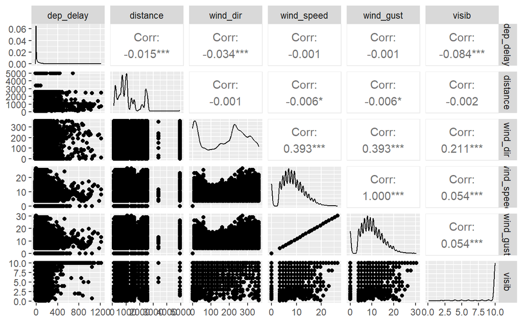

```r
# part 1 EWR only (weather_1_ewr_delay_num.png)
weather_delay %>%
  filter(origin == "EWR") %>%
  select(dep_delay, distance, wind_dir, wind_speed, wind_gust, visib) %>%
  ggpairs(progress = FALSE)
```

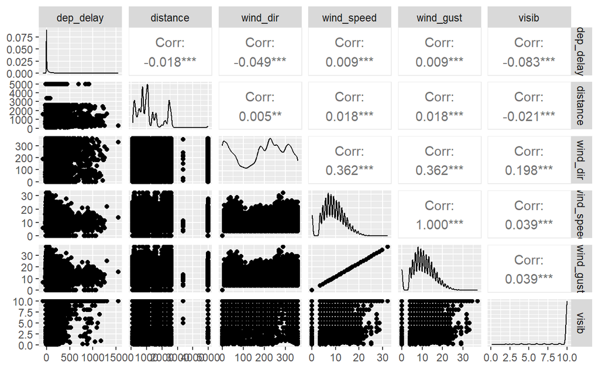

```r
# part 1 all airports (weather_1_all_delay_num.png)
weather_delay %>%
  select(dep_delay, distance, wind_dir, wind_speed, wind_gust, visib) %>%
  ggpairs(progress = FALSE)
```

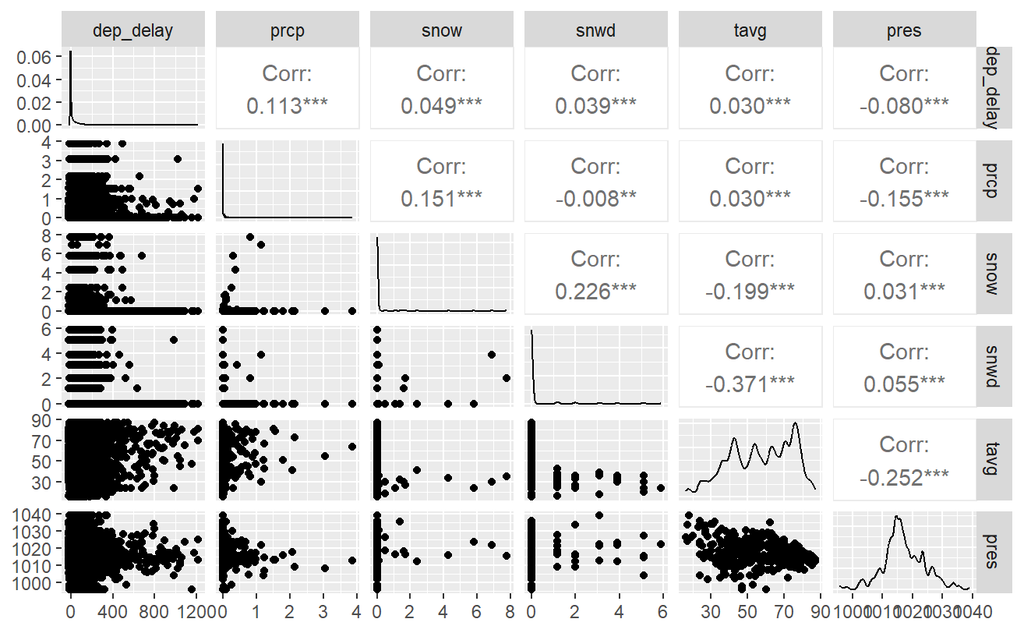

```r
# part 2 EWR only (weather_2_ewr_delay_num.png)
weather_delay %>%
  filter(origin == "EWR") %>%
  select(dep_delay, prcp, snow, snwd, tavg, pres) %>%
  ggpairs(progress = FALSE)
```

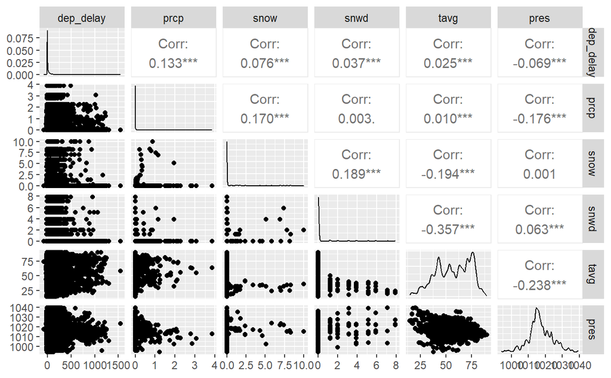

```r
# part 2 all airports (weather_2_all_delay_num.png)
weather_delay %>%
  select(dep_delay,prcp, snow, snwd, tavg, pres) %>%
  ggpairs(progress = FALSE)
```

### Against delay flag

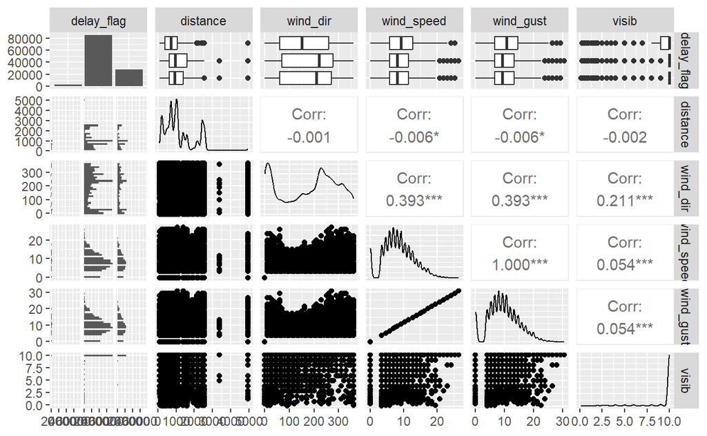

```r
# part 1 EWR only (weather_1_ewr_delay_flag.png)
weather_delay %>%
  filter(origin == "EWR") %>%
  select(delay_flag, distance, wind_dir, wind_speed, wind_gust, visib) %>%
  ggpairs(progress = FALSE)
```

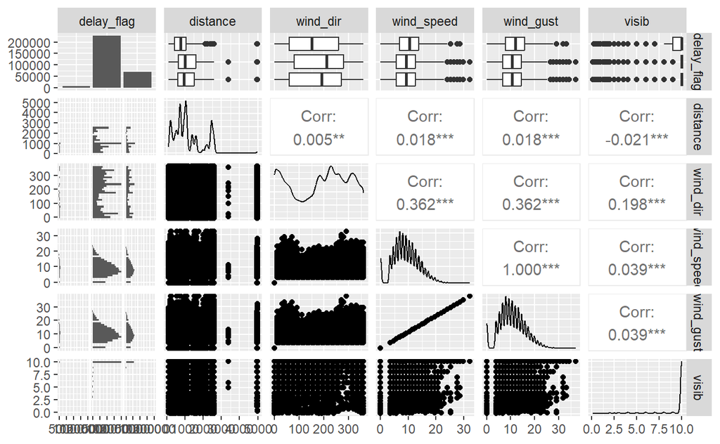

```r
# part 1 all airports (weather_1_all_delay_flag.png)
weather_delay %>%
  select(delay_flag, distance, wind_dir, wind_speed, wind_gust, visib) %>%
  ggpairs(progress = FALSE)
```

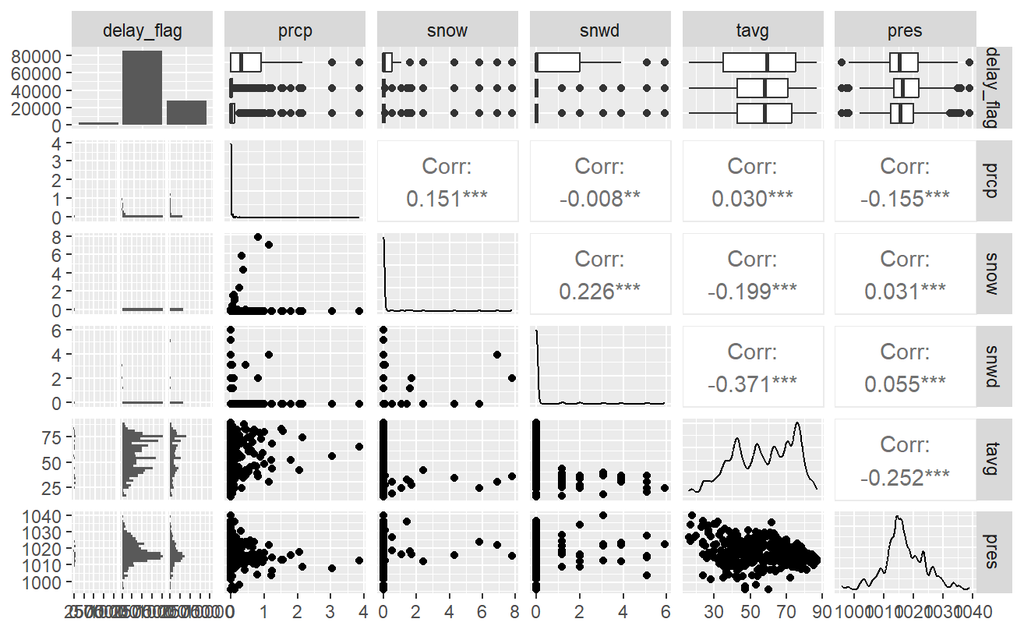

```r
# part 2 EWR only (weather_2_ewr_delay_flag.png)
weather_delay %>%
  filter(origin == "EWR") %>%
  select(delay_flag, prcp, snow, snwd, tavg, pres) %>%
  ggpairs(progress = FALSE)
```

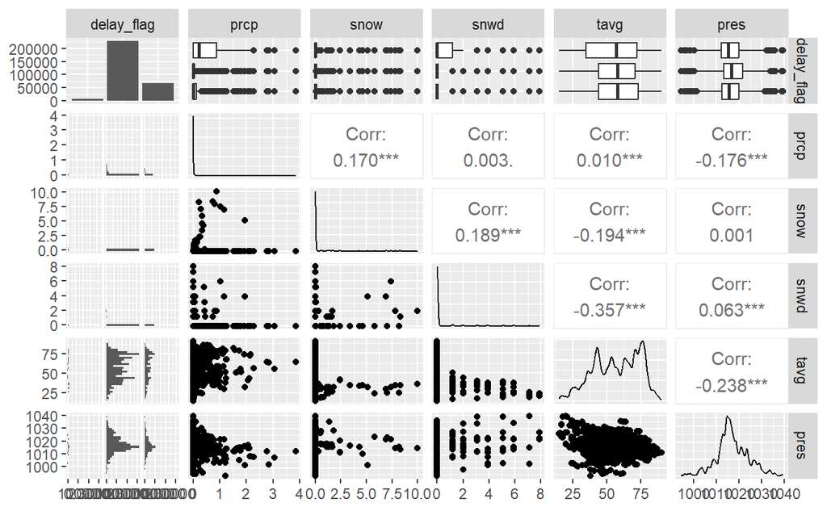

```r
# part 2 all airports (weather_2_all_delay_flag.png)
weather_delay %>%
  select(delay_flag, prcp, snow, snwd, tavg, pres) %>%
  ggpairs(progress = FALSE)
```

## Correlation with airport factors and type of flight

```r
airport_delay <- final_df %>%
  select(sch_departure, origin, dest, dep_delay, delay_flag, carrier, flight,
         distance, lat.y, lon.y, nose_dir2)
```

### Against numerical delay

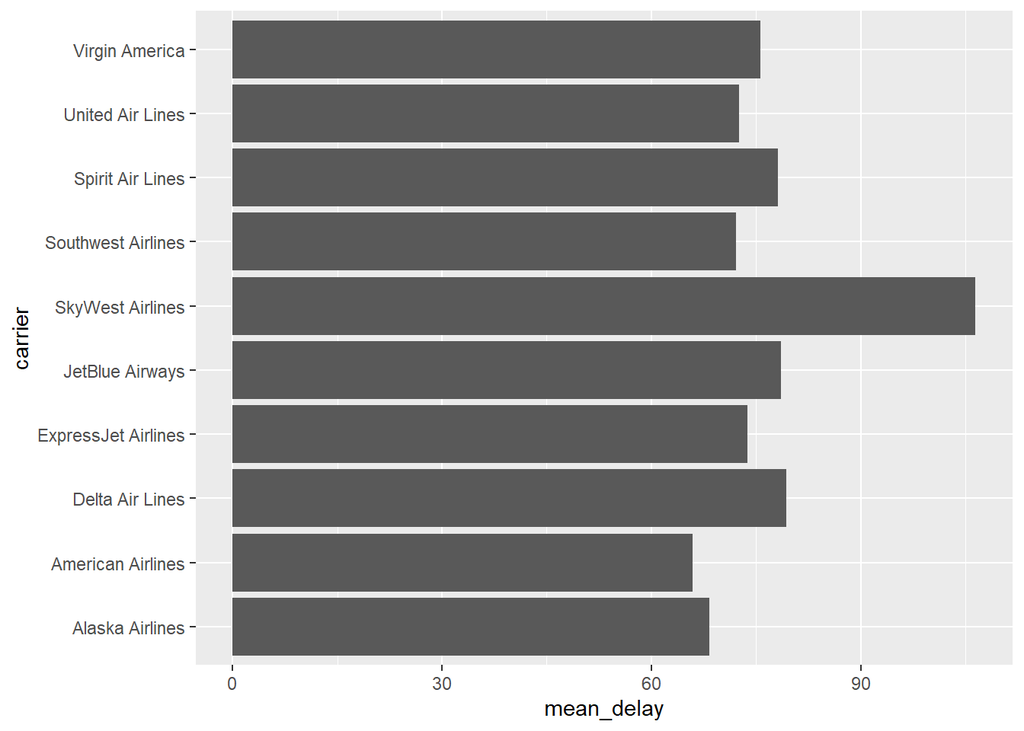

```r
# EWR only
airport_delay %>%
  filter(origin == "EWR",
         dep_delay > 15) %>%
  group_by(carrier) %>%
  summarise(mean_delay = mean(dep_delay, na.rm = TRUE)) %>%
  ggplot(aes(x = mean_delay, y = carrier))+
  geom_col()
```

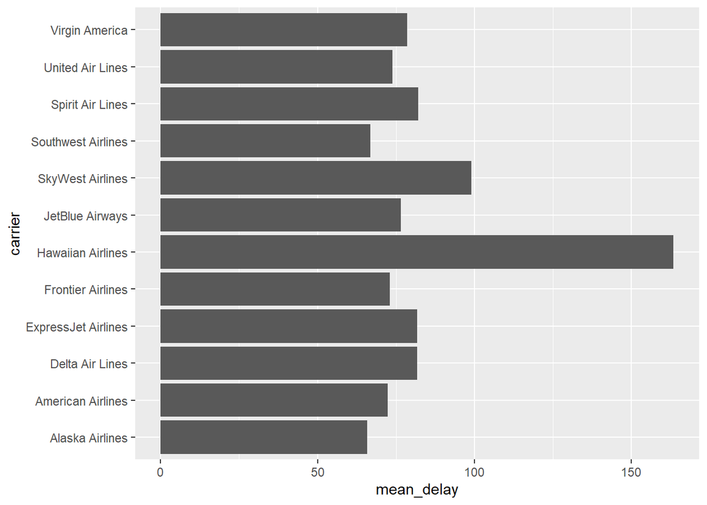

```r
# all airports
airport_delay %>%
  filter(dep_delay > 15) %>%
  group_by(carrier) %>%
  summarise(mean_delay = mean(dep_delay, na.rm = TRUE)) %>%
  ggplot(aes(x = mean_delay, y = carrier))+
  geom_col()
```

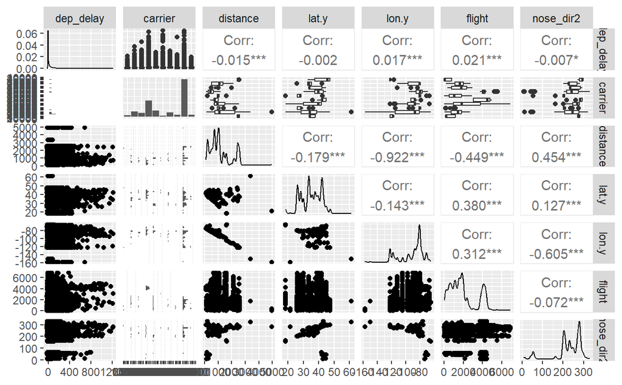

```r
# EWR only (airport_ewr_delay_num.png)
airport_delay %>%
  filter(origin == "EWR") %>%
  select(dep_delay, carrier, distance, lat.y, lon.y, flight, nose_dir2) %>%
  ggpairs(progress = FALSE)
```

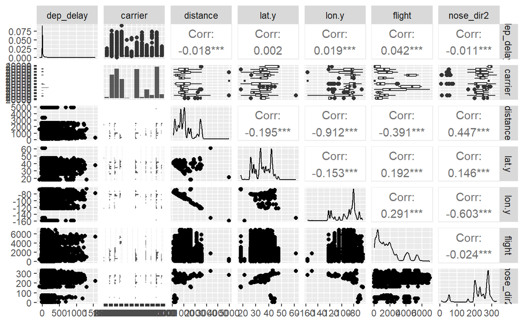

```r
# all airlines (airport_all_delay_num.png)
airport_delay %>%
  select(dep_delay, carrier, distance, lat.y, lon.y, flight, nose_dir2) %>%
  ggpairs(progress = FALSE)
```

### Against delay flag

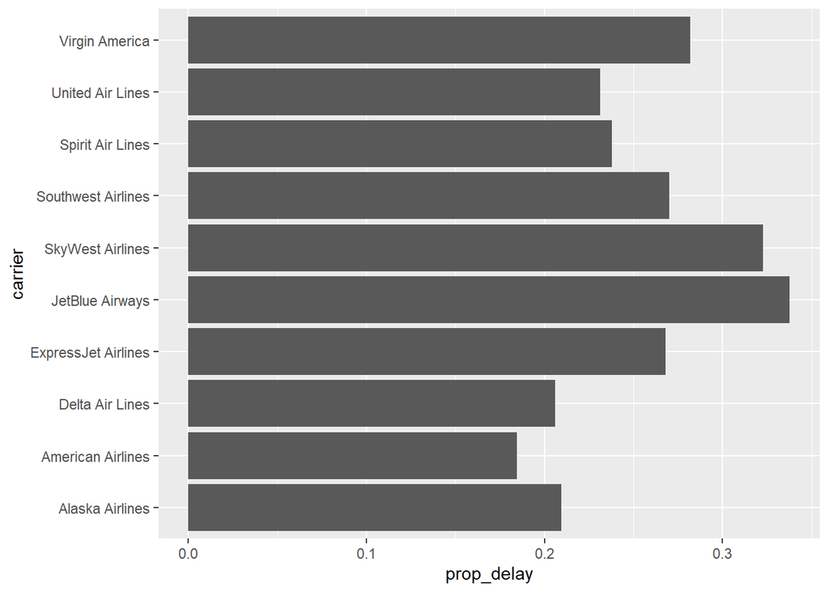

```r
# EWR only
airport_delay %>%
  filter(!is.na(dep_delay),
         origin == "EWR") %>%
  group_by(carrier) %>%
  summarise(prop_delay = sum(delay_flag == "Yes") / n()) %>%
  ggplot(aes(x = prop_delay, y = carrier))+
  geom_col()
```

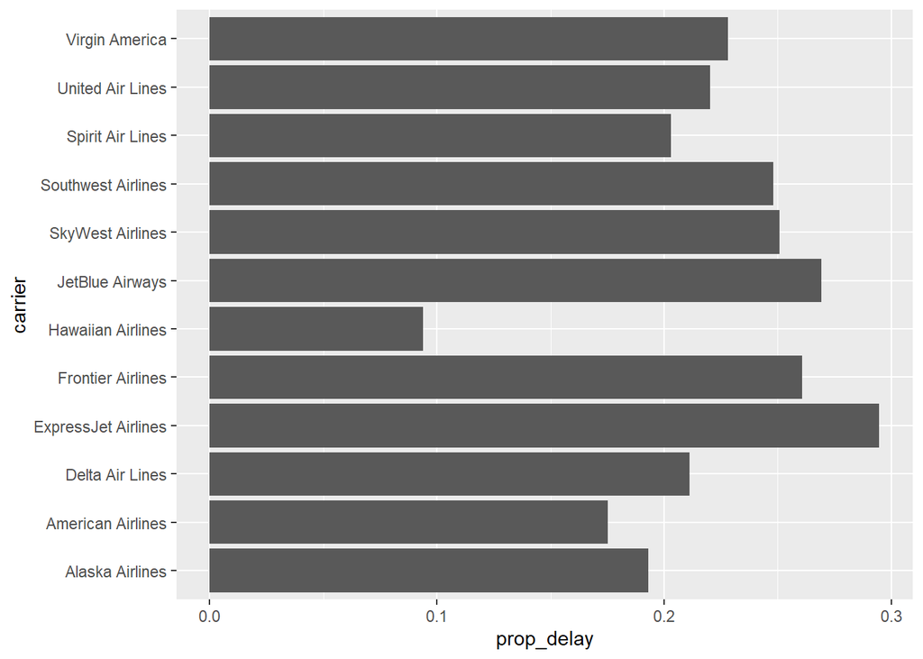

```r
# all airports
airport_delay %>%
  filter(!is.na(dep_delay)) %>%
  group_by(carrier) %>%
  summarise(prop_delay = sum(delay_flag == "Yes") / n()) %>%
  ggplot(aes(x = prop_delay, y = carrier))+
  geom_col()
```

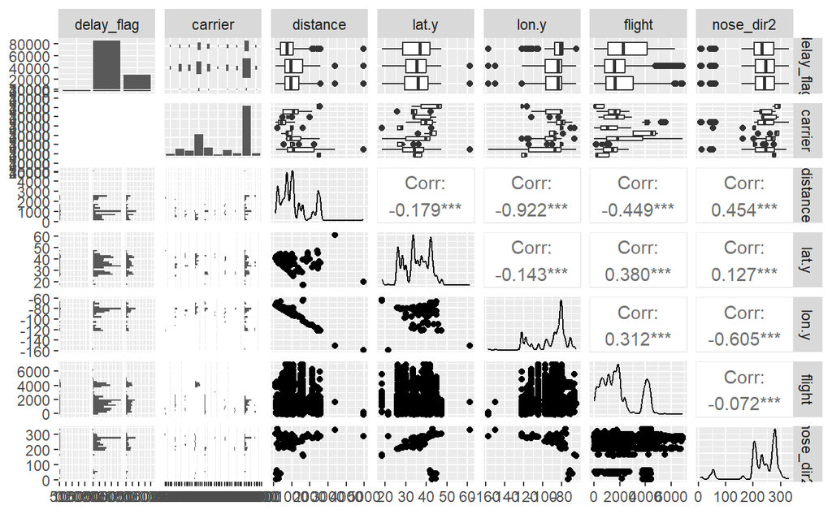

```r
# EWR only (images/airport_ewr_delay_flag.png)
airport_delay %>%
  filter(origin == "EWR") %>%
  select(delay_flag, carrier, distance, lat.y, lon.y, flight, nose_dir2) %>%
  ggpairs(progress = FALSE)
```

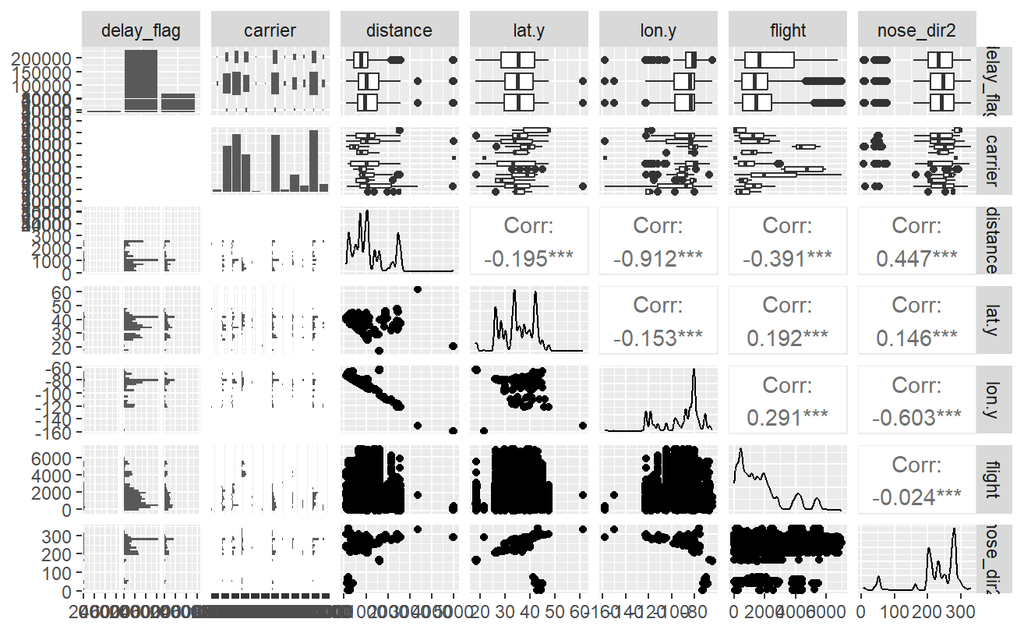

```r
# All airports (airport_all_delay_flag.png)
airport_delay %>%
  select(delay_flag, carrier, distance, lat.y, lon.y, flight, nose_dir2) %>%
  ggpairs(progress = FALSE)
```

## Correlation with plane details

```r
plane_delay <- final_df %>%
  select(sch_departure, origin, dest, dep_delay, delay_flag, tailnum,
         year, type, manufacturer, model, engines, seats,
         speed, engine)
```

```r
plane_delay %>%
  count(type)
```

```
## # A tibble: 5 × 2
##   type                          n
##   <chr>                     <int>
## 1 Fixed wing multi engine  254207
## 2 Fixed wing single engine   9844
## 3 Rotorcraft                 1269
## 4 Weight-shift-control         62
## 5 <NA>                      38366
```

```r
plane_delay %>%
  count(manufacturer)
```

```
## # A tibble: 74 × 2
##    manufacturer              n
##    <chr>                 <int>
##  1 AERO COMMANDER           70
##  2 AIR TRACTOR INC         708
##  3 AIRBUS                50164
##  4 AIRBUS INDUSTRIE      30959
##  5 AMERICAN AIRCRAFT INC    24
##  6 ANGER ANTHONY B          21
##  7 ANTARES                  20
##  8 ARCH AERIAL LLC          72
##  9 ASTRAEUS AERIAL LLC     312
## 10 AVIAT AIRCRAFT INC      246
## # ℹ 64 more rows
```

```r
plane_delay %>%
  count(model)
```

```
## # A tibble: 223 × 2
##    model     n
##    <chr> <int>
##  1 150G     16
##  2 150M     21
##  3 152     336
##  4 172K     21
##  5 172L    320
##  6 172M     53
##  7 172N     23
##  8 172S     20
##  9 180      29
## 10 180J     16
## # ℹ 213 more rows
```

```r
plane_delay %>%
  count(engines)
```

```
## # A tibble: 6 × 2
##   engines      n
##     <dbl>  <int>
## 1       1  10514
## 2       2 253646
## 3       3    553
## 4       4    285
## 5       8    384
## 6      NA  38366
```

```r
plane_delay %>%
  count(seats)
```

```
## # A tibble: 61 × 2
##    seats     n
##    <dbl> <int>
##  1     1   714
##  2     2  2461
##  3     4  4520
##  4     5  1065
##  5     6  1403
##  6     7  1264
##  7     8   697
##  8     9    81
##  9    10   642
## 10    11   510
## # ℹ 51 more rows
```

```r
plane_delay %>%
  count(speed)
```

```
## # A tibble: 26 × 2
##    speed     n
##    <dbl> <int>
##  1    76    22
##  2    81    21
##  3    90    92
##  4   100    19
##  5   105   364
##  6   107     7
##  7   108    53
##  8   111    48
##  9   112    77
## 10   120    16
## # ℹ 16 more rows
```

```r
plane_delay %>%
  count(engine)
```

```
## # A tibble: 9 × 2
##   engine             n
##   <chr>          <int>
## 1 2 Cycle           62
## 2 4 Cycle          546
## 3 Electric         631
## 4 Reciprocating   9297
## 5 Turbo-fan     243979
## 6 Turbo-jet       8459
## 7 Turbo-prop      2084
## 8 Turbo-shaft      324
## 9 <NA>           38366
```

It is not expected that year of manufacture or manufacturer will affect the delays, therefore these will be excluded.

### Against numerical delay

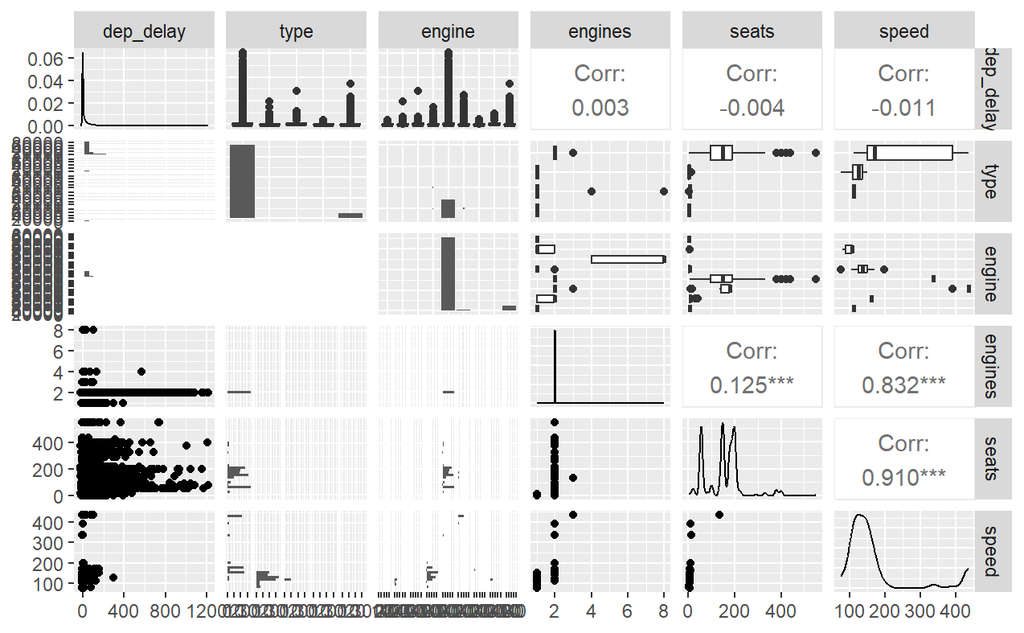

```r
# EWR only (plane_ewr_delay_num.png)
plane_delay %>%
  filter(origin == "EWR") %>%
  select(dep_delay, type, engine, engines, seats, speed) %>%
  ggpairs(progress = FALSE)
```

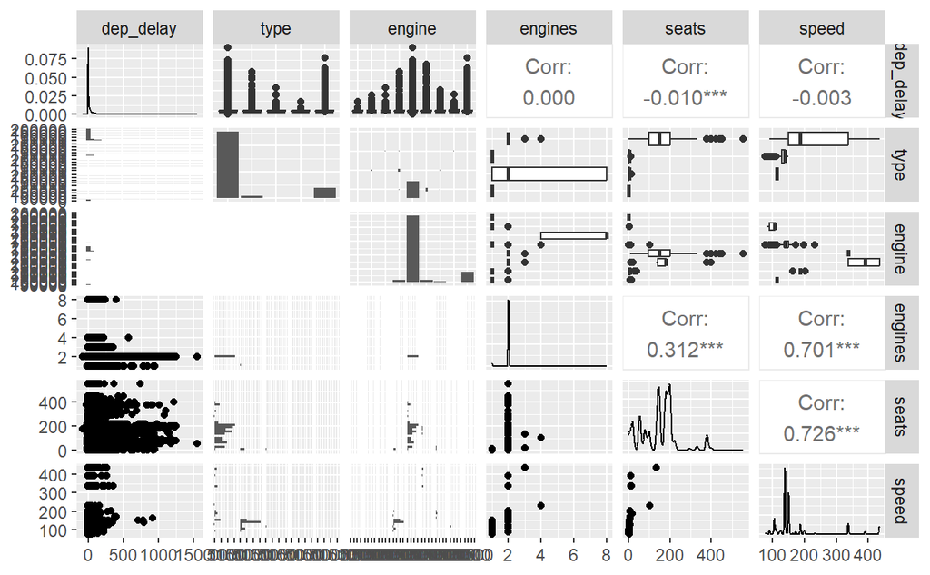

```r
# all airports (plane_all_delay_num.png)
plane_delay %>%
  select(dep_delay, type, engine, engines, seats, speed) %>%
  ggpairs(progress = FALSE)
```

### Against delay flag

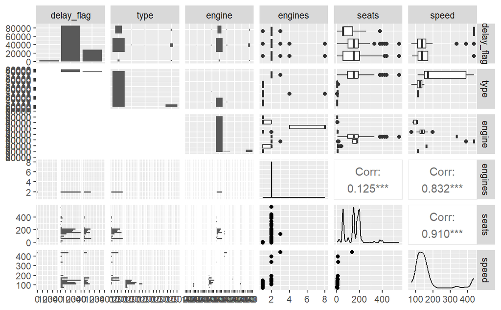

```r
# EWR only (plane_ewr_delay_flag.png)
plane_delay %>%
  filter(origin == "EWR") %>%
  select(delay_flag, type, engine, engines, seats, speed) %>%
  ggpairs(progress = FALSE)
```

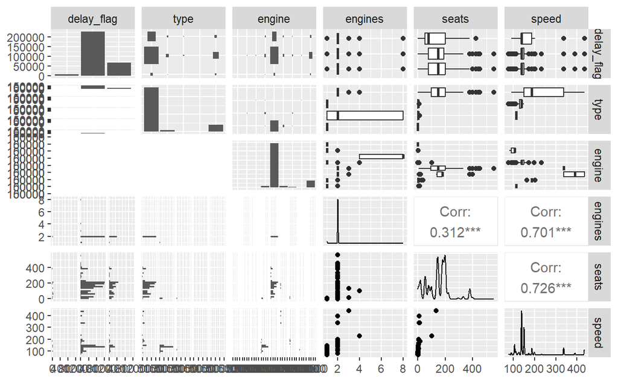

```r
# all airports (plane_all_delay_flag.png)
plane_delay %>%
  select(delay_flag, type, engine, engines, seats, speed) %>%
  ggpairs(progress = FALSE)
```

## Summary

### Weather details

From the first variables plotted against `dep_delay`, there does not seem to be any direct correlations between those weather variables and flight delay. There does however appear to be a direct correlation between `wind_speed` and `wind_gust`. `wind_dir` appears to have an slight correlation to `wind_gust`/`wind_speed` and `visib`. This appears to also be the case when uwing `delay_flag` instead of `dep_delay`.

From the second variables plotted against `dep_delay`, there does not seem to be any direct correlations between those weather variables and flight delay. `prcp` seems to be the highest. There does appear to be a good correlation between temperature and pressure, and between temperature and snow depth.

As weather factors form part of the primary remit, only `wind_gust` will be removed as a result of the correlation plots.

### Airport and flight details

There does not seem to be any direct correlations between these variables and flight delay. There is a very high correlation between destination longitude and `distance`, and between destination longitude and `nose_dir2`.

`long` and `lat` will be removed as a result of the correlation plots.

### Plane details

Will only keep `type` and `seats`, mainly as seats can be used to infer airport traffic.

# Final list of variables to keep

```r
final_trim <- final_df %>%
  select(sch_departure, origin, dep_delay, delay_flag, # origin
         dest, distance, nose_dir2, # destination
         carrier, type, seats, # airline/airplane
         wind_dir, wind_speed, visib, prcp, snow, snwd, tavg, pres) # weather
```

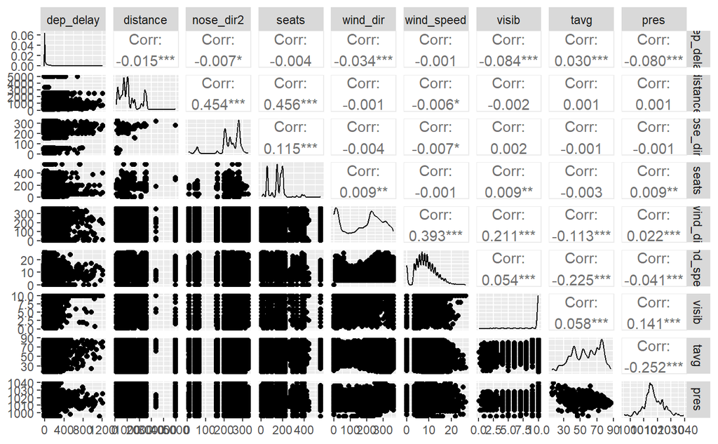

```r
# full ggpairs() on weather and factors affecting plane size and direction
# (final_variables_delay_num.png)
final_trim %>%
  filter(origin == "EWR") %>%
  select(dep_delay, distance, nose_dir2, seats,
         wind_dir, wind_speed, visib, tavg, pres) %>%
  ggpairs(progress = FALSE)
```

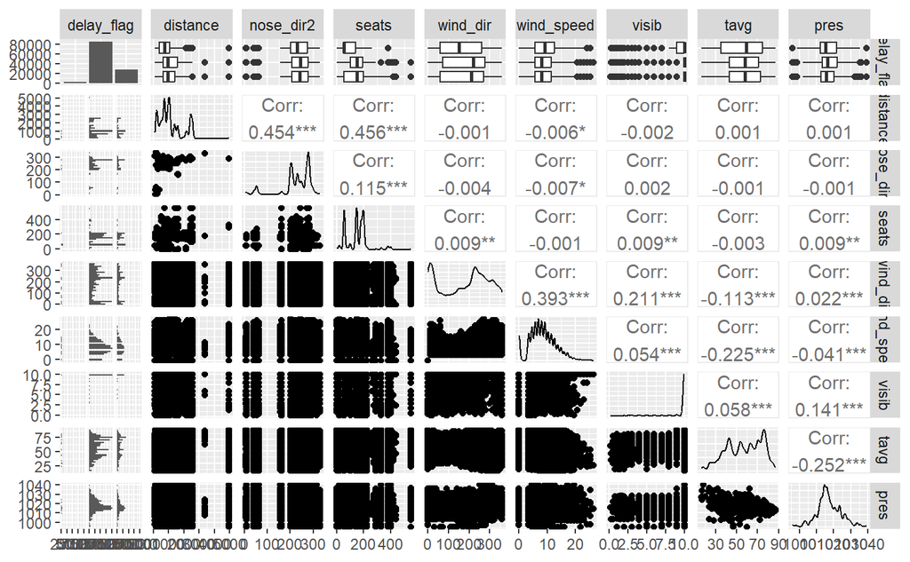

```r
# full ggpairs() on weather and factors affecting plane size and direction
# (final_variables_delay_flag.png)
final_trim %>%
  filter(origin == "EWR") %>%
  select(delay_flag, distance, nose_dir2, seats,
         wind_dir, wind_speed, visib, tavg, pres) %>%
  ggpairs(progress = FALSE)
```